# Questionnaire analysis example

Niklas Edvall

2023-09-14

This is report and script provide an example on how to use R Markdown to create an analysis report from questionnaire data. Most code chunks are included in this report to make it easy to follow.

### Research questions

Using questionnaire data and sociodemographics we investigate

1. Is the score on the Tinnitus Handicap Inventory (THI) questionnaire affected by age?
2. Do older participants take longer to answer the online questionnaires?

### Load data

Load data as data frame named *dat* using readr-package and display the first 5 rows and 10 columns to inspect data. Note that date and time format are specified for columns containing such data.

```r
dat <- read_csv("data/Data.csv",
                col_types = cols(logindate = col_date(format = "%Y-%m-%d"),   # Date format
                                                  logintime = col_time(format = "%H:%M:%S"),   # Time format
                                                  logofftime = col_time(format = "%H:%M:%S"))) # Time format

head(dat, n = c(5,10))
```

```
## # A tibble: 5 x 10
##      ID logindate  logintime logofftime item.1 item.2 item.3 THI_1 THI_2 THI_3
##   <dbl> <date>     <time>    <time>      <dbl>  <dbl>  <dbl> <dbl> <dbl> <dbl>
## 1     1 2023-07-16 12:26:16  12:56:16        1     48      3     2     4     2
## 2     2 2023-09-05 12:05:56  12:25:56        2     39      3     2     0     0
## 3     3 2023-05-17 08:57:41  09:22:41        1     37      4     2     0     0
## 4     4 2023-06-02 08:58:49  09:02:49        1     78      3     4     4     4
## 5     5 2023-09-24 16:32:47  16:50:47        2     38      2     0     2     2
```

### Specify and rename some parameters

```r
# Factor (categorical variables)
dat$item.1 <- factor(dat$item.1, levels = c(1,2), labels = c("M", "F"))
dat$item.3 <- factor(dat$item.3, levels = c(1,2,3,4), labels = c("No", "Sometimes", "Often", "Always"))

# Rename variables
names(dat)[names(dat) == "item.1"] <- "sex"
names(dat)[names(dat) == "item.2"] <- "age"
names(dat)[names(dat) == "item.3"] <- "hearing"
```

### Calculate new variables

Using the function apply() we sum columns with names in the created variable *THI.names* for each row in the data frame. This way we create a new variable (*THIscore*) with the THI total score for each participant. We also calculate the time spend online by taking the time of logging in (the variable *logintime*) away from the time the participant logged off (the variable *logofftime*). We divide this value by 60 to represent the time in minutes and transform it to a numeric variable from a time-variable using the function as.numeric(). We call this new variable *t.online*.

```r
#Create list of names that match names of THI items in data
THI.names <- paste("THI", seq(1:25), sep="_")

# Calculate new variables of interest
dat$THIscore <- apply(dat[,THI.names], 1, FUN=sum)
dat$t.online <- as.numeric((dat$logofftime - dat$logintime)/60) #divide by 60 for minutes
```

### Descriptive table

Using the package *arsenal* to create a descriptive table (named *tab1*) of Male and Female participants separately. Include p-value from statistical test to show no difference between Male and Female participants. Note to specify *results=‘asis’* for code-chunk to get table output as html

```r
# Descriptive table
tab1 <- tableby(sex ~ age + hearing + THIscore, data = dat, digits = 1, total = FALSE)

summary(tab1, pfootnote = TRUE)
```

|  | M (N=25) | F (N=24) | p value |
| --- | --- | --- | --- |
| **age** |  |  | 0.428<sup>1</sup> |
| Mean (SD) | 55.1 (16.5) | 51.8 (12.3) |  |
| Range | 27.0 - 78.0 | 35.0 - 76.0 |  |
| **hearing** |  |  | 0.352<sup>2</sup> |
| No | 3 (12.0%) | 6 (25.0%) |  |
| Sometimes | 9 (36.0%) | 4 (16.7%) |  |
| Often | 6 (24.0%) | 8 (33.3%) |  |
| Always | 7 (28.0%) | 6 (25.0%) |  |
| **THIscore** |  |  | 0.179<sup>1</sup> |
| Mean (SD) | 52.4 (6.3) | 49.7 (7.7) |  |
| Range | 42.0 - 66.0 | 34.0 - 60.0 |  |

1. Linear Model ANOVA
2. Pearson’s Chi-squared test

### Question 1, plot and regression

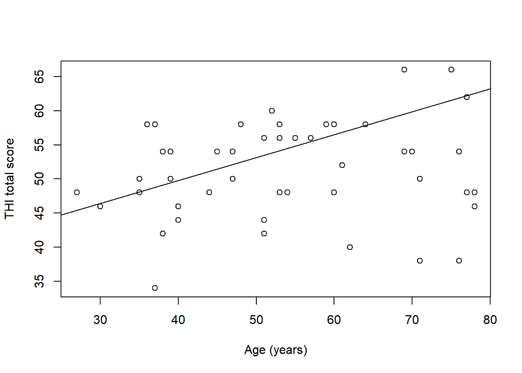

```r
# Plot THI score as function of age ==================================
plot(dat$age, dat$THIscore, xlab = "Age (years)", ylab = "THI total score") #Scatter plot
abline(lm(dat$age ~ dat$THIscore)) #Linear regression line
```

```r
# Calculate linear regression model for age ~ THIscore
lin.mod1 <- lm(dat$THIscore ~ dat$age)
summary(lin.mod1)
```

```
##
## Call:
## lm(formula = dat$THIscore ~ dat$age)
##
## Residuals:
##      Min       1Q   Median       3Q      Max
## -15.7449  -3.9843   0.3392   4.9779  13.7006
##
## Coefficients:
##             Estimate Std. Error t value Pr(>|t|)
## (Intercept) 46.79117    3.88028   12.06 5.45e-16 ***
## dat$age      0.07983    0.07006    1.14     0.26
## ---
## Signif. codes:  0 '***' 0.001 '**' 0.01 '*' 0.05 '.' 0.1 ' ' 1
##
## Residual standard error: 7.05 on 47 degrees of freedom
## Multiple R-squared:  0.02688,    Adjusted R-squared:  0.00618
## F-statistic: 1.298 on 1 and 47 DF,  p-value: 0.2603
```

### Question 2, plot and regression

To answer question 2 we show a scatter plot of *t.online* as a function of *age* and overlay it with a best-fit linear regression line. We again show the summary output of the linear regression model.

There is no relationship between age and time spent on page.

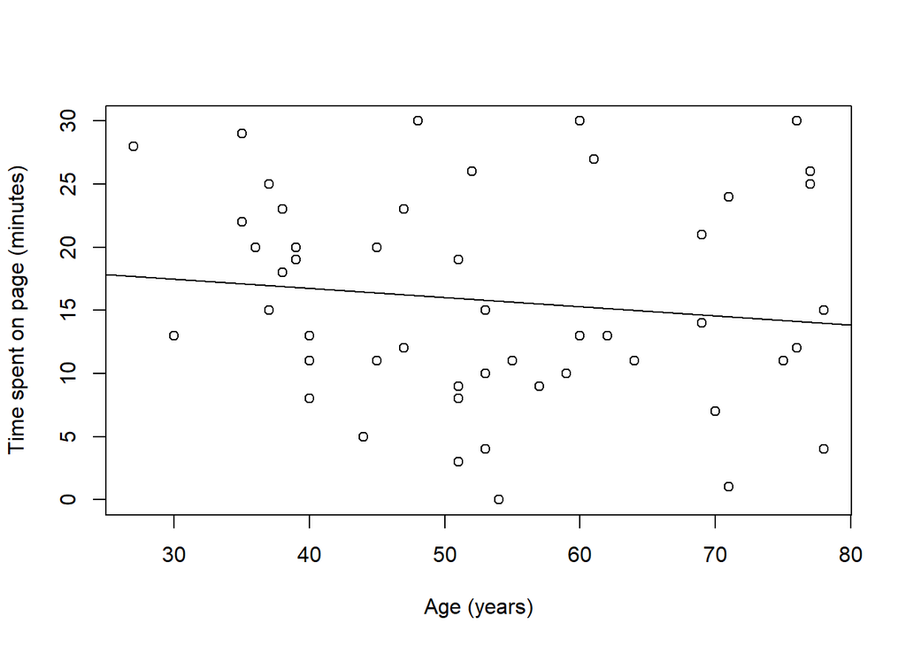

```r
# Plot THI score as function of age ==================================
plot(dat$age, dat$t.online, xlab = "Age (years)", ylab = "Time spent on page (minutes)") #Scatter plot
abline(lm(dat$t.online ~ dat$age)) #Linear regression line
```

```r
# Calculate linear regression model for age ~ THIscore
lin.mod2 <- lm(dat$t.online ~ dat$age)
summary(lin.mod2)
```

```
##
## Call:
## lm(formula = dat$t.online ~ dat$age)
##
## Residuals:
##     Min      1Q  Median      3Q     Max
## -15.739  -5.746  -1.962   6.340  15.844
##
## Coefficients:
##             Estimate Std. Error t value Pr(>|t|)
## (Intercept) 19.62349    4.58372   4.281 9.09e-05 ***
## dat$age     -0.07194    0.08276  -0.869    0.389
## ---
## Signif. codes:  0 '***' 0.001 '**' 0.01 '*' 0.05 '.' 0.1 ' ' 1
##
## Residual standard error: 8.329 on 47 degrees of freedom
## Multiple R-squared:  0.01582,    Adjusted R-squared:  -0.005117
## F-statistic: 0.7557 on 1 and 47 DF,  p-value: 0.3891
```

### Histogram

We look at a histogram of *t.online* and see that a few participants spent less than 5 minutes on the page and should probably excluded as this is sufficient time. We create a new data frame (*dat.exc*) with only those who spent more than 5 minutes on page (i.e *t.online* > 5) and excluding everyone who spent less than 5 minutes. Comparing the number of rows between the old and new data frames show that n = 6 participants got excluded.

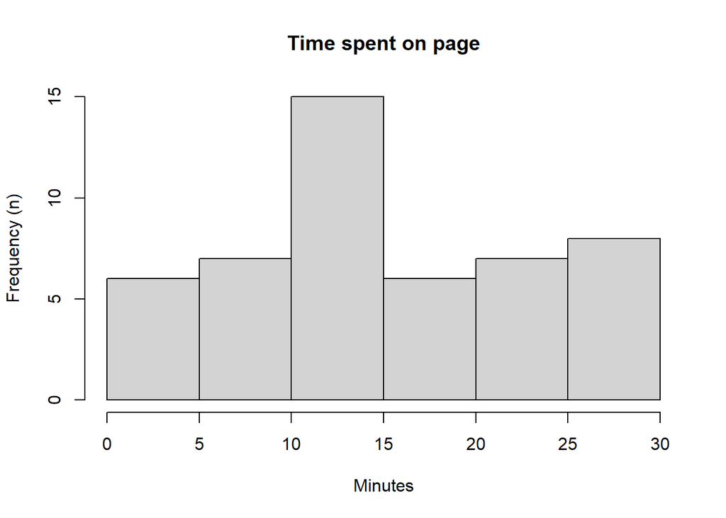

```r
hist(dat$t.online, main = "Time spent on page", xlab = "Minutes", ylab = "Frequency (n)")
```

```r
dat.exc <- dat[dat$t.online > 5, ]

nrow(dat) - nrow(dat.exc)
```

```
## [1] 6
```